## PRACTICAL MACHINE LEARNING WEEK 4: COURSE PROJECT - Case Study on Exercise Data

# Problem Statement

By - Arshdeep Singh

Using devices such as Jawbone Up, Nike FuelBand, and Fitbit it is now possible to collect a large amount of data about personal activity relatively inexpensively. These type of devices are part of the quantified self movement - a group of enthusiasts who take measurements about themselves regularly to improve their health, to find patterns in their behavior, or because they are tech geeks.

One thing that people regularly do is quantify how much of a particular activity they do, but they rarely quantify how well they do it. In this project, we will use data recorded from accelerometers on the belt, forearm, arm, and dumbbell of 6 participants. They were asked to perform barbell lifts correctly and incorrectly in 5 different ways.

More information is available from the website http://groupware.les.inf.puc-rio.br/har (see the section on the Weight Lifting Exercise Dataset).

The goal of this project is to predict the manner in which the participants did the exercise. This is the classe variable of the training set, which classifies the correct and incorrect outcomes into A, B, C, D, and E categories.

This write-up describes my approach to the problem outlined above in predicting the ‘classe’ of the 20 questions posed as the final exam of the course Practical Machine Learning offered by John Hopkins University from May 30th - June 27 (2016)

# Input Data [1]

The training data for this project are available here: https://d396qusza40orc.cloudfront.net/predmachlearn/pml-training.csv The test data are available here: https://d396qusza40orc.cloudfront.net/predmachlearn/pml-testing.csv

# Summary of Approach Idea:

The course outlines a chain of stages for a predictor which is the basis of my attack on this problem:

1.) Question —>2.) Input Data —>3.) Features —> 4.) Algorithm —>5.) Parameters —>6.) Evaluation

The question has been descirbed in the beginning. Let’s load the input data into the environment first.

```r
library(AppliedPredictiveModeling)
library(caret)
library(rattle)
```

```r
library(rpart.plot)
set.seed(12345789)

setwd("D:/coursera-pml")
training <- read.csv("pml-training.csv", na.strings = c("NA", "#DIV/0!", ""))
testing  <- read.csv("pml-testing.csv",  na.strings = c("NA", "#DIV/0!", ""))

colnames_train <- colnames(training)
colnames_test <- colnames(testing)
# Verify that the column names (excluding classe and problem_id) are identical in the training and test set.
all.equal(colnames_train[1:length(colnames_train)-1], colnames_test[1:length(colnames_train)-1])
```

```
## [1] TRUE
```

```r
# Get an idea of the number of observation for each class
table(training$classe)
```

```
##
##    A    B    C    D    E
## 5580 3797 3422 3216 3607
```

```r
prop.table(table(training$classe))
```

```
##
##         A         B         C         D         E
## 0.2843747 0.1935073 0.1743961 0.1638977 0.1838243
```

```r
#Removing variables such as 'user_name', '*timestamps*'
training <- training[, 7:160]
testing  <- testing[, 7:160]

is_data  <- apply(!is.na(training), 2, sum) >= 19622  # which is the number of observations
training <- training[, is_data]
testing  <- testing[, is_data]
```

# Partitioning the data

Let’s partition the data for cross-validation:

```r
inTrain <- createDataPartition(y=training$classe, p=0.60, list=FALSE)
train1  <- training[inTrain,]
train2  <- training[-inTrain,]
dim(train1)
```

```
## [1] 11776    54
```

```r
dim(train2)
```

```
## [1] 7846   54
```

We have successfully built our training-only data(train1) and testing-only data(train2) from our cleaned up data called training. ‘train2’ shall be used for cross-validation.

# Features

Further lets [i] In ‘train1’ let’s identify the “zero covariates” and [ii] remove the very same “zero covariates”" from both train1 and train2

```r
nzv_cols <- nearZeroVar(train1)
if(length(nzv_cols) > 0) {
  train1 <- train1[, -nzv_cols]
  train2 <- train2[, -nzv_cols]
}
dim(train1)
```

```
## [1] 11776    54
```

```r
dim(train2)
```

```
## [1] 7846   54
```

```r
library(randomForest)
```

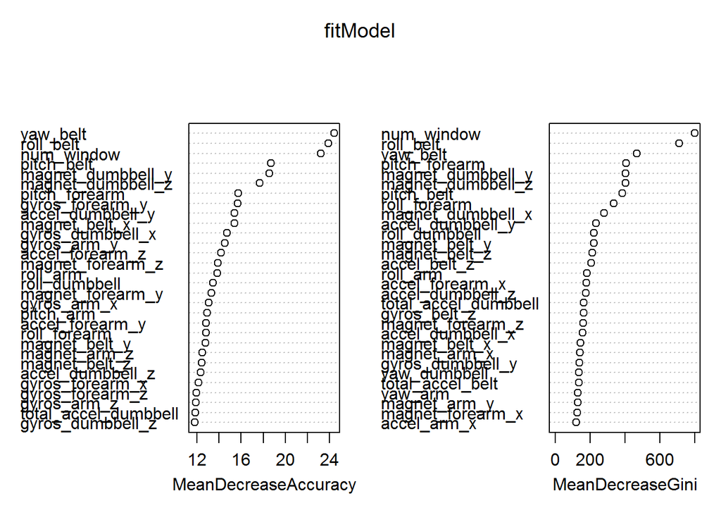

```r
fitModel <- randomForest(classe~., data=train1, importance=TRUE, ntree=100)
varImpPlot(fitModel)
```

Let’s use the top 10 features described by the above plots to build our models. If the accuracy of prediction obtained is fairly low we can reconsider this decision of pruning features but for now let’s move forward with the same.

```r
correl = cor(train1[,c("yaw_belt","roll_belt","pitch_belt","magnet_dumbbell_y","magnet_dumbbell_z","pitch_forearm","gyros_forearm_y","accel_dumbbell_y","magnet_belt_x")])
diag(correl) <- 0
which(abs(correl)>0.80, arr.ind=TRUE)
```

```
##               row col
## roll_belt       2   1
## yaw_belt        1   2
## magnet_belt_x   9   3
## pitch_belt      3   9
```

```r
cor(train1$roll_belt, train1$yaw_belt)
```

```
## [1] 0.8145056
```

```r
cor(train1$magnet_belt_x, train1$pitch_belt)
```

```
## [1] -0.8894303
```

Let’s remove one variable from these two pairs to move ahead. I’ll be doing away with yaw_belt and magnet_belt_x

```r
correl = cor(train1[,c("roll_belt","pitch_belt","magnet_dumbbell_y","magnet_dumbbell_z","pitch_forearm","gyros_forearm_y","accel_dumbbell_y")])
diag(correl) <- 0
maxCorrel <- max(correl)
maxCorrel
```

```
## [1] 0.4911048
```

```r
which(correl == maxCorrel, arr.ind = TRUE)
```

```
##                   row col
## accel_dumbbell_y    7   3
## magnet_dumbbell_y   3   7
```

We see that the correlation now has dropped down to ~ 49% between accel_dumbbell_y & magnet_dumbbell_y Their correlation is safe to move ahead.

After plotting two features against each other colored according to classe we find an interesting realtionship between roll_belt & magnet_dumbbell_y

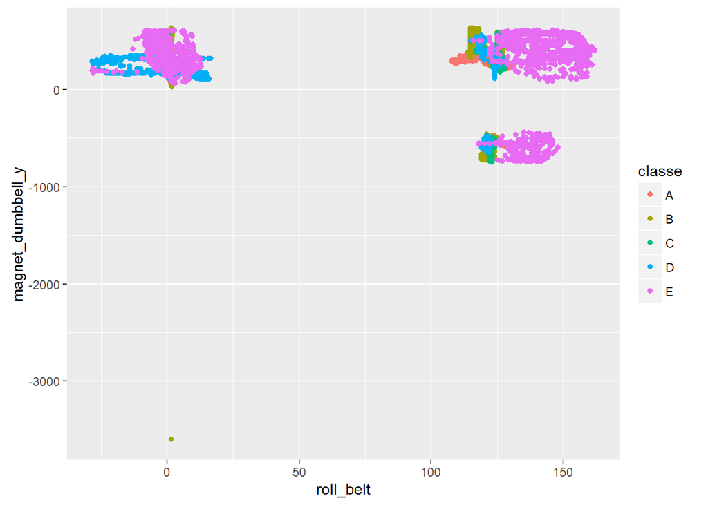

```r
qplot(roll_belt, magnet_dumbbell_y, colour=classe, data=train1)
```

We could probably categorize the data into groups based on roll_belt values. Let’s cross verify using decision trees.

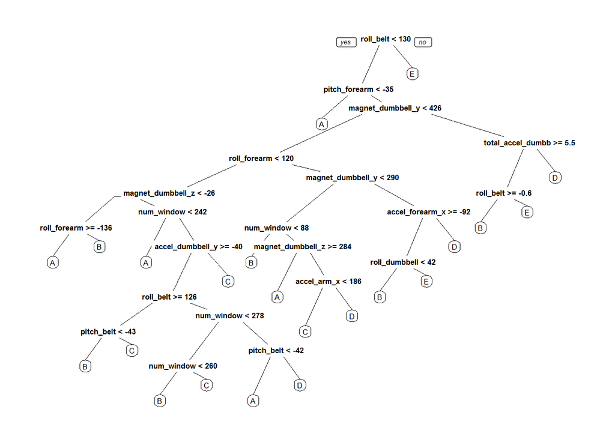

```r
fitModel <- rpart(classe~., data=train1, method="class")
prp(fitModel)
```

Our observation from qplot is aligned with our observation from decision trees. roll_belt is the foremost classifying variable.

# Modelling

```r
set.seed(23449202)
fitModel <- train(classe~roll_belt+num_window+pitch_belt+magnet_dumbbell_y+magnet_dumbbell_z+pitch_forearm+gyros_forearm_y+roll_arm+accel_dumbbell_y,
                  data=train1,
                  method="rf",
                  trControl=trainControl(method="cv",number=2),
                  prox=TRUE,
                  verbose=TRUE,
                  allowParallel=TRUE)
```

# Accuracy (Cross-Validation)

We use confusionMatrix on train2 for an estimate of how accurate our model is ?

```r
predictions <- predict(fitModel, newdata=train2)
confusionMat <- confusionMatrix(predictions, train2$classe)
confusionMat
```

```
## Confusion Matrix and Statistics
##
##           Reference
## Prediction    A    B    C    D    E
##          A 2231    0    0    0    0
##          B    1 1518    4    0    4
##          C    0    0 1364    1    0
##          D    0    0    0 1285    1
##          E    0    0    0    0 1437
##
## Overall Statistics
##
##                Accuracy : 0.9986
##                  95% CI : (0.9975, 0.9993)
##     No Information Rate : 0.2845
##     P-Value [Acc > NIR] : < 2.2e-16
##
##                   Kappa : 0.9982
##  Mcnemar's Test P-Value : NA
##
## Statistics by Class:
##
##                      Class: A Class: B Class: C Class: D Class: E
## Sensitivity            0.9996   1.0000   0.9971   0.9992   0.9965
## Specificity            1.0000   0.9986   0.9998   0.9998   1.0000
## Pos Pred Value         1.0000   0.9941   0.9993   0.9992   1.0000
## Neg Pred Value         0.9998   1.0000   0.9994   0.9998   0.9992
## Prevalence             0.2845   0.1935   0.1744   0.1639   0.1838
## Detection Rate         0.2843   0.1935   0.1738   0.1638   0.1832
## Detection Prevalence   0.2843   0.1946   0.1740   0.1639   0.1832
## Balanced Accuracy      0.9998   0.9993   0.9985   0.9995   0.9983
```

As you can see the accuracy is 99.8 % .

# Out of Sample Error

```r
missClass = function(values, predicted) {
  sum(predicted != values) / length(values)
}
OOS_errRate = missClass(train2$classe, predictions)
OOS_errRate
```

```
## [1] 0.001401988
```

The out-of-samle error = 0.14 %

We are sure of this result because we have cross-validated our resulted.

# References:

[1] Velloso, E.; Bulling, A.; Gellersen, H.; Ugulino, W.; Fuks, H. Qualitative Activity Recognition of Weight Lifting Exercises. Proceedings of 4th International Conference in Cooperation with SIGCHI (Augmented Human ’13) . Stuttgart, Germany: ACM SIGCHI, 2013.

Read more: http://groupware.les.inf.puc-rio.br/har#ixzz4C1NsQnz1